# Выбор локации для скважины

# Описание проекта

Допустим, вы работаете в добывающей компании «ГлавРосГосНефть». Нужно решить, где бурить новую скважину.

Шаги для выбора локации:

- В избранном регионе ищут месторождения, для каждого определяют значения признаков;
- Строят модель и оценивают объём запасов;
- Выбирают месторождения с самым высокими оценками значений. Количество месторождений зависит от бюджета компании и стоимости разработки одной скважины;
- Прибыль равна суммарной прибыли отобранных месторождений.

**Условия задачи:**

- Для обучения модели подходит только линейная регрессия (остальные — недостаточно предсказуемые).
- При разведке региона исследуют 500 точек, из которых с помощью машинного обучения выбирают 200 лучших для разработки.
- Бюджет на разработку скважин в регионе — 10 млрд рублей.
- При нынешних ценах один баррель сырья приносит 450 рублей дохода. Доход с каждой единицы продукта составляет 450 тыс. рублей, поскольку объём указан в тысячах баррелей.
- После оценки рисков нужно оставить лишь те регионы, в которых вероятность убытков меньше 2.5%. Среди них выбирают регион с наибольшей средней прибылью.

Данные синтетические: детали контрактов и характеристики месторождений не разглашаются.

# Цель проекта

Решение задачи регрессии и обучения с учителем.

Построить модель машинного обучения, для предсказания объёма запасов нефти в месторождениях для каждого региона. На основе предсказаний выбрать месторождения с наибольшими запасами, рассчитать потенциальную прибыль и оценить риски с использованием техники Bootstrap.

# Описание данных

Данные геологоразведки трёх регионов находятся в файлах:

- `/datasets/geo_data_0.csv`
- `/datasets/geo_data_1.csv`
- `/datasets/geo_data_2.csv`

Признаки:

- `'id'` — уникальный идентификатор скважины;
- `'f0'`, `'f1'`, `'f2'` — три признака точек (неважно, что они означают, но сами признаки значимы);
- `'product'` — объём запасов в скважине (тыс. баррелей).

# План работы

1. Загрузите и подготовьте данные. Поясните порядок действий.
1. Обучите и проверьте модель для каждого региона:

   2.1. Разбейте данные на обучающую и валидационную выборки в соотношении 75:25.

   2.2. Обучите модель и сделайте предсказания на валидационной выборке.

   2.3. Сохраните предсказания и правильные ответы на валидационной выборке.

   2.4. Напечатайте на экране средний запас предсказанного сырья и RMSE модели.

   2.5. Проанализируйте результаты.
1. Подготовьтесь к расчёту прибыли:

   3.1. Все ключевые значения для расчётов сохраните в отдельных переменных.

   3.2. Рассчитайте достаточный объём сырья для безубыточной разработки новой скважины. Сравните полученный объём сырья со средним запасом в каждом регионе.

   3.3. Напишите выводы по этапу подготовки расчёта прибыли.
1. Напишите функцию для расчёта прибыли по выбранным скважинам и предсказаниям модели:

   4.1. Выберите скважины с максимальными значениями предсказаний.

   4.2. Просуммируйте целевое значение объёма сырья, соответствующее этим предсказаниям.

   4.3. Рассчитайте прибыль для полученного объёма сырья.
1. Посчитайте риски и прибыль для каждого региона:

   5.1. Примените технику Bootstrap с 1000 выборок, чтобы найти распределение прибыли.

   5.2. Найдите среднюю прибыль, 95%-й доверительный интервал и риск убытков. Убыток — это отрицательная прибыль.

   5.3. Напишите выводы: предложите регион для разработки скважин и обоснуйте выбор.

## Загрузка и подготовка данных

### Импорт библиотек

```python
import pandas as pd
import numpy as np
import matplotlib.pyplot as plt
import seaborn as sns


from IPython.display import HTML
from statsmodels.stats.outliers_influence import variance_inflation_factor
from sklearn.model_selection import train_test_split
from sklearn.pipeline import Pipeline
from sklearn.preprocessing import StandardScaler
from sklearn.linear_model import LinearRegression


from sklearn.metrics import(
    mean_squared_error,
    mean_absolute_error,
    r2_score
)


!pip install phik -q
import phik
```

```python
RANDOM_STATE = 42
```

### Создание функций

Создадим функции, которые нам потребуются в работе.

```python
# Функция для предварительного изучения
# общей информации о данных.
def data_research(dataset):

    display(dataset.head())
    display(dataset.tail())
    print()


    display(HTML('<h3>Общая информация о данных</h3><br>'))
    print(dataset.info())


    display(HTML('<h3>Наименования столбцов</h3><br>'))
    print(dataset.columns)



    display(HTML('<br><h3>Количество пропущенных значений</h3><br>'))

    if dataset.isna().sum().any():


        print(dataset.isna().sum())

        display(HTML('<br><h3>Доля пропущенных значений</h3><br>'))
        display(HTML(
            f'<b>Во всем датафрейме: </b>'\
            f'{round((dataset.isna().sum().sum() / (dataset.shape[0] * dataset.shape[1]) * 100), 1)}%<br>')
            )

        display(HTML('<b>В каждом столбце: </b>'))
        display(pd.DataFrame(dataset.isna().mean()*100)\
                .style.set_precision(1).background_gradient('coolwarm'))

    else:
        print('Пропущенные значения отсутствуют')


    display(HTML('<br><h3>Количество дубликатов в датафрейме</h3><br>'))

    print(f'Всего: {dataset.duplicated().sum()} '
          f'({(dataset.duplicated().sum() / dataset.shape[0]):.2%} '\
          f'от общего размера)')



    if len(dataset.select_dtypes(include=[np.number]).columns) != 0:

        display(HTML('<br><h3>Описание данных</h3>'))
        display(dataset.describe())

        display(HTML('<br><h3>Гистограммы для всех числовых столбцов</h3><br>'))
        axes = dataset.hist(figsize=(10, 10), xlabelsize=10, ylabelsize=10)

        # Добавляем подписи осей
        for ax in axes.flatten():
            ax.set_xlabel(ax.get_title(), fontsize=12)
            ax.set_ylabel('Количество записей', fontsize=12)

        plt.tight_layout()
        plt.show()

    else:
        pass
```

```python
# Функция для построения графиков для количественных признаков.
def int_plot(data, column):
    # Создаем фигуру с двумя подграфиками (2 строки, 1 столбец).
    fig, axs = plt.subplots(2, 1, figsize=(15, 10))

    # График распределения.
    sns.histplot(data=data,
                 x=column,
                 ax=axs[0],
                 kde=True,
                 bins=20)
    axs[0].grid(True)
    axs[0].set_xlabel(column, fontsize=12)
    axs[0].set_ylabel('Количество скважин', fontsize=12)

    # Диаграмма размаха (боксплот).
    sns.boxplot(data=data, x=column, ax=axs[1])
    axs[1].grid(True)
    axs[1].set_xlabel(column, fontsize=12)

    # Общий заголовок для графиков.
    plt.suptitle(f'График распределения и '\
                 f'диаграмма размаха значений столбца "{column}"',
                 fontsize=14)
    plt.tight_layout()
    plt.show()
```

### Загрузка данных

Загружаем данные из csv-файла в датафрейм.

```python
region_1 = pd.read_csv('/datasets/geo_data_0.csv')
region_2 = pd.read_csv('/datasets/geo_data_1.csv')
region_3 = pd.read_csv('/datasets/geo_data_2.csv')
```

Сохраним все датафреймы в одной переменной для удобства обращения к ним в повторяющихся операциях.

```python
all_data = ['region_1', 'region_2', 'region_3']
```

### Изучение общей информации о датафреймах

Изучим информацию при помощи функции `data_research`.

Датафрейм `region_1`

|  | id | f0 | f1 | f2 | product |
| --- | --- | --- | --- | --- | --- |
| 0 | txEyH | 0.705745 | -0.497823 | 1.221170 | 105.280062 |
| 1 | 2acmU | 1.334711 | -0.340164 | 4.365080 | 73.037750 |
| 2 | 409Wp | 1.022732 | 0.151990 | 1.419926 | 85.265647 |
| 3 | iJLyR | -0.032172 | 0.139033 | 2.978566 | 168.620776 |
| 4 | Xdl7t | 1.988431 | 0.155413 | 4.751769 | 154.036647 |

|  | id | f0 | f1 | f2 | product |
| --- | --- | --- | --- | --- | --- |
| 99995 | DLsed | 0.971957 | 0.370953 | 6.075346 | 110.744026 |
| 99996 | QKivN | 1.392429 | -0.382606 | 1.273912 | 122.346843 |
| 99997 | 3rnvd | 1.029585 | 0.018787 | -1.348308 | 64.375443 |
| 99998 | 7kl59 | 0.998163 | -0.528582 | 1.583869 | 74.040764 |
| 99999 | 1CWhH | 1.764754 | -0.266417 | 5.722849 | 149.633246 |

Общая информация о данных

```
<class 'pandas.core.frame.DataFrame'>
RangeIndex: 100000 entries, 0 to 99999
Data columns (total 5 columns):
 #   Column   Non-Null Count   Dtype
---  ------   --------------   -----
 0   id       100000 non-null  object
 1   f0       100000 non-null  float64
 2   f1       100000 non-null  float64
 3   f2       100000 non-null  float64
 4   product  100000 non-null  float64
dtypes: float64(4), object(1)
memory usage: 3.8+ MB
None
```

Наименования столбцов

```
Index(['id', 'f0', 'f1', 'f2', 'product'], dtype='object')
```

Количество пропущенных значений

```
Пропущенные значения отсутствуют
```

Количество дубликатов в датафрейме

```
Всего: 0 (0.00% от общего размера)
```

Описание данных

|  | f0 | f1 | f2 | product |
| --- | --- | --- | --- | --- |
| count | 100000.000000 | 100000.000000 | 100000.000000 | 100000.000000 |
| mean | 0.500419 | 0.250143 | 2.502647 | 92.500000 |
| std | 0.871832 | 0.504433 | 3.248248 | 44.288691 |
| min | -1.408605 | -0.848218 | -12.088328 | 0.000000 |
| 25% | -0.072580 | -0.200881 | 0.287748 | 56.497507 |
| 50% | 0.502360 | 0.250252 | 2.515969 | 91.849972 |
| 75% | 1.073581 | 0.700646 | 4.715088 | 128.564089 |
| max | 2.362331 | 1.343769 | 16.003790 | 185.364347 |

Гистограммы для всех числовых столбцов

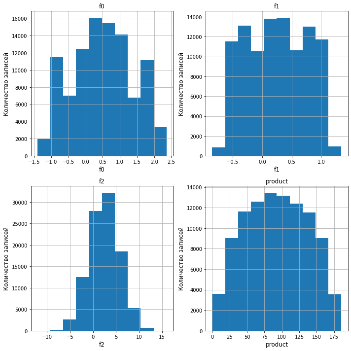

Датафрейм `region_2`

|  | id | f0 | f1 | f2 | product |
| --- | --- | --- | --- | --- | --- |
| 0 | kBEdx | -15.001348 | -8.276000 | -0.005876 | 3.179103 |
| 1 | 62mP7 | 14.272088 | -3.475083 | 0.999183 | 26.953261 |
| 2 | vyE1P | 6.263187 | -5.948386 | 5.001160 | 134.766305 |
| 3 | KcrkZ | -13.081196 | -11.506057 | 4.999415 | 137.945408 |
| 4 | AHL4O | 12.702195 | -8.147433 | 5.004363 | 134.766305 |

|  | id | f0 | f1 | f2 | product |
| --- | --- | --- | --- | --- | --- |
| 99995 | QywKC | 9.535637 | -6.878139 | 1.998296 | 53.906522 |
| 99996 | ptvty | -10.160631 | -12.558096 | 5.005581 | 137.945408 |
| 99997 | 09gWa | -7.378891 | -3.084104 | 4.998651 | 137.945408 |
| 99998 | rqwUm | 0.665714 | -6.152593 | 1.000146 | 30.132364 |
| 99999 | relB0 | -3.426139 | -7.794274 | -0.003299 | 3.179103 |

Общая информация о данных

```
<class 'pandas.core.frame.DataFrame'>
RangeIndex: 100000 entries, 0 to 99999
Data columns (total 5 columns):
 #   Column   Non-Null Count   Dtype
---  ------   --------------   -----
 0   id       100000 non-null  object
 1   f0       100000 non-null  float64
 2   f1       100000 non-null  float64
 3   f2       100000 non-null  float64
 4   product  100000 non-null  float64
dtypes: float64(4), object(1)
memory usage: 3.8+ MB
None
```

Наименования столбцов

```
Index(['id', 'f0', 'f1', 'f2', 'product'], dtype='object')
```

Количество пропущенных значений

```
Пропущенные значения отсутствуют
```

Количество дубликатов в датафрейме

```
Всего: 0 (0.00% от общего размера)
```

Описание данных

|  | f0 | f1 | f2 | product |
| --- | --- | --- | --- | --- |
| count | 100000.000000 | 100000.000000 | 100000.000000 | 100000.000000 |
| mean | 1.141296 | -4.796579 | 2.494541 | 68.825000 |
| std | 8.965932 | 5.119872 | 1.703572 | 45.944423 |
| min | -31.609576 | -26.358598 | -0.018144 | 0.000000 |
| 25% | -6.298551 | -8.267985 | 1.000021 | 26.953261 |
| 50% | 1.153055 | -4.813172 | 2.011479 | 57.085625 |
| 75% | 8.621015 | -1.332816 | 3.999904 | 107.813044 |
| max | 29.421755 | 18.734063 | 5.019721 | 137.945408 |

Гистограммы для всех числовых столбцов

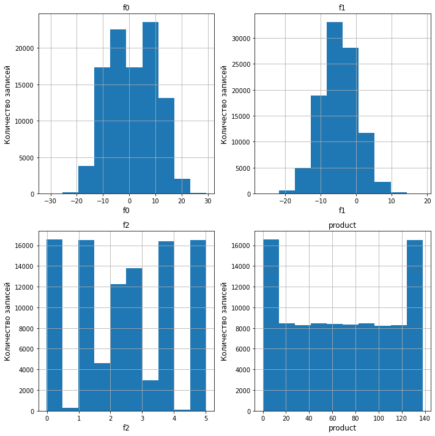

Датафрейм `region_3`

|  | id | f0 | f1 | f2 | product |
| --- | --- | --- | --- | --- | --- |
| 0 | fwXo0 | -1.146987 | 0.963328 | -0.828965 | 27.758673 |
| 1 | WJtFt | 0.262778 | 0.269839 | -2.530187 | 56.069697 |
| 2 | ovLUW | 0.194587 | 0.289035 | -5.586433 | 62.871910 |
| 3 | q6cA6 | 2.236060 | -0.553760 | 0.930038 | 114.572842 |
| 4 | WPMUX | -0.515993 | 1.716266 | 5.899011 | 149.600746 |

|  | id | f0 | f1 | f2 | product |
| --- | --- | --- | --- | --- | --- |
| 99995 | 4GxBu | -1.777037 | 1.125220 | 6.263374 | 172.327046 |
| 99996 | YKFjq | -1.261523 | -0.894828 | 2.524545 | 138.748846 |
| 99997 | tKPY3 | -1.199934 | -2.957637 | 5.219411 | 157.080080 |
| 99998 | nmxp2 | -2.419896 | 2.417221 | -5.548444 | 51.795253 |
| 99999 | V9kWn | -2.551421 | -2.025625 | 6.090891 | 102.775767 |

Общая информация о данных

```
<class 'pandas.core.frame.DataFrame'>
RangeIndex: 100000 entries, 0 to 99999
Data columns (total 5 columns):
 #   Column   Non-Null Count   Dtype
---  ------   --------------   -----
 0   id       100000 non-null  object
 1   f0       100000 non-null  float64
 2   f1       100000 non-null  float64
 3   f2       100000 non-null  float64
 4   product  100000 non-null  float64
dtypes: float64(4), object(1)
memory usage: 3.8+ MB
None
```

Наименования столбцов

```
Index(['id', 'f0', 'f1', 'f2', 'product'], dtype='object')
```

Количество пропущенных значений

```
Пропущенные значения отсутствуют
```

Количество дубликатов в датафрейме

```
Всего: 0 (0.00% от общего размера)
```

Описание данных

|  | f0 | f1 | f2 | product |
| --- | --- | --- | --- | --- |
| count | 100000.000000 | 100000.000000 | 100000.000000 | 100000.000000 |
| mean | 0.002023 | -0.002081 | 2.495128 | 95.000000 |
| std | 1.732045 | 1.730417 | 3.473445 | 44.749921 |
| min | -8.760004 | -7.084020 | -11.970335 | 0.000000 |
| 25% | -1.162288 | -1.174820 | 0.130359 | 59.450441 |
| 50% | 0.009424 | -0.009482 | 2.484236 | 94.925613 |
| 75% | 1.158535 | 1.163678 | 4.858794 | 130.595027 |
| max | 7.238262 | 7.844801 | 16.739402 | 190.029838 |

Гистограммы для всех числовых столбцов

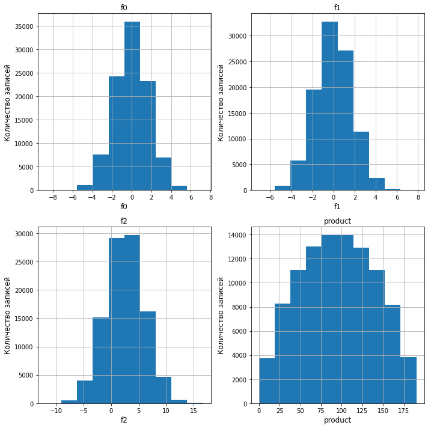

```python
for data_name in all_data:
    data = eval(data_name)

    display(HTML(f'<br><br><br><h1>Датафрейм `{data_name}`</h1>'))

    data_research(data)
```

### Вывод

Данные загружены, они соответствуют описанию задачи. Всего у нас представлено данных о 100 000 скважинах по каждому из трех регионов.

Наименования столбцов соответствуют стандартам оформления данных, типы данных в столбцах соответствуют их содержимому, аномальных значений в графиках не наблюдается. Пропуски и дубликаты отсутствуют.

Вернуться к содержанию

## Предобработка данных

### Устранение дубликатов

В данных отсутствуют явные дубликаты, поэтому проверим на наличие дубликатов среди ID скважин.

```python
for data_name in all_data:
    data = eval(data_name)

    display(HTML(f'<br><br><h1>Датафрейм `{data_name}`</h1>'))

    value_counts = data['id'].value_counts()
    filtered_counts = value_counts[value_counts >= 2]

    display(HTML(f'<b>Уникальные значения в столбце "id": </b>'\
                 f'{len(filtered_counts)}'))

    print(filtered_counts.to_string())

    for i in filtered_counts.index:
        display(data[data['id'] == i])
```

Датафрейм `region_1`

**Уникальные значения в столбце "id":** 10

```
A5aEY    2
Tdehs    2
HZww2    2
AGS9W    2
TtcGQ    2
bsk9y    2
bxg6G    2
QcMuo    2
fiKDv    2
74z30    2
```

|  | id | f0 | f1 | f2 | product |
| --- | --- | --- | --- | --- | --- |
| 3389 | A5aEY | -0.039949 | 0.156872 | 0.209861 | 89.249364 |
| 51970 | A5aEY | -0.180335 | 0.935548 | -2.094773 | 33.020205 |

|  | id | f0 | f1 | f2 | product |
| --- | --- | --- | --- | --- | --- |
| 21426 | Tdehs | 0.829407 | 0.298807 | -0.049563 | 96.035308 |
| 75715 | Tdehs | 0.112079 | 0.430296 | 3.218993 | 60.964018 |

|  | id | f0 | f1 | f2 | product |
| --- | --- | --- | --- | --- | --- |
| 931 | HZww2 | 0.755284 | 0.368511 | 1.863211 | 30.681774 |
| 7530 | HZww2 | 1.061194 | -0.373969 | 10.430210 | 158.828695 |

|  | id | f0 | f1 | f2 | product |
| --- | --- | --- | --- | --- | --- |
| 42529 | AGS9W | 1.454747 | -0.479651 | 0.683380 | 126.370504 |
| 69163 | AGS9W | -0.933795 | 0.116194 | -3.655896 | 19.230453 |

|  | id | f0 | f1 | f2 | product |
| --- | --- | --- | --- | --- | --- |
| 60140 | TtcGQ | 0.569276 | -0.104876 | 6.440215 | 85.350186 |
| 92341 | TtcGQ | 0.110711 | 1.022689 | 0.911381 | 101.318008 |

|  | id | f0 | f1 | f2 | product |
| --- | --- | --- | --- | --- | --- |
| 89582 | bsk9y | 0.398908 | -0.400253 | 10.122376 | 163.433078 |
| 97785 | bsk9y | 0.378429 | 0.005837 | 0.160827 | 160.637302 |

|  | id | f0 | f1 | f2 | product |
| --- | --- | --- | --- | --- | --- |
| 1364 | bxg6G | 0.411645 | 0.856830 | -3.653440 | 73.604260 |
| 41724 | bxg6G | -0.823752 | 0.546319 | 3.630479 | 93.007798 |

|  | id | f0 | f1 | f2 | product |
| --- | --- | --- | --- | --- | --- |
| 1949 | QcMuo | 0.506563 | -0.323775 | -2.215583 | 75.496502 |
| 63593 | QcMuo | 0.635635 | -0.473422 | 0.862670 | 64.578675 |

|  | id | f0 | f1 | f2 | product |
| --- | --- | --- | --- | --- | --- |
| 16633 | fiKDv | 0.157341 | 1.028359 | 5.585586 | 95.817889 |
| 90815 | fiKDv | 0.049883 | 0.841313 | 6.394613 | 137.346586 |

|  | id | f0 | f1 | f2 | product |
| --- | --- | --- | --- | --- | --- |
| 64022 | 74z30 | 0.741456 | 0.459229 | 5.153109 | 140.771492 |
| 66136 | 74z30 | 1.084962 | -0.312358 | 6.990771 | 127.643327 |

Датафрейм `region_2`

**Уникальные значения в столбце "id":** 4

```
wt4Uk    2
LHZR0    2
bfPNe    2
5ltQ6    2
```

|  | id | f0 | f1 | f2 | product |
| --- | --- | --- | --- | --- | --- |
| 47591 | wt4Uk | -9.091098 | -8.109279 | -0.002314 | 3.179103 |
| 82873 | wt4Uk | 10.259972 | -9.376355 | 4.994297 | 134.766305 |

|  | id | f0 | f1 | f2 | product |
| --- | --- | --- | --- | --- | --- |
| 1305 | LHZR0 | 11.170835 | -1.945066 | 3.002872 | 80.859783 |
| 41906 | LHZR0 | -8.989672 | -4.286607 | 2.009139 | 57.085625 |

|  | id | f0 | f1 | f2 | product |
| --- | --- | --- | --- | --- | --- |
| 2721 | bfPNe | -9.494442 | -5.463692 | 4.006042 | 110.992147 |
| 82178 | bfPNe | -6.202799 | -4.820045 | 2.995107 | 84.038886 |

|  | id | f0 | f1 | f2 | product |
| --- | --- | --- | --- | --- | --- |
| 5849 | 5ltQ6 | -3.435401 | -12.296043 | 1.999796 | 57.085625 |
| 84461 | 5ltQ6 | 18.213839 | 2.191999 | 3.993869 | 107.813044 |

Датафрейм `region_3`

**Уникальные значения в столбце "id":** 4

```
xCHr8    2
Vcm5J    2
VF7Jo    2
KUPhW    2
```

|  | id | f0 | f1 | f2 | product |
| --- | --- | --- | --- | --- | --- |
| 28039 | xCHr8 | 1.633027 | 0.368135 | -2.378367 | 6.120525 |
| 43233 | xCHr8 | -0.847066 | 2.101796 | 5.597130 | 184.388641 |

|  | id | f0 | f1 | f2 | product |
| --- | --- | --- | --- | --- | --- |
| 44378 | Vcm5J | -1.229484 | -2.439204 | 1.222909 | 137.968290 |
| 95090 | Vcm5J | 2.587702 | 1.986875 | 2.482245 | 92.327572 |

|  | id | f0 | f1 | f2 | product |
| --- | --- | --- | --- | --- | --- |
| 11449 | VF7Jo | 2.122656 | -0.858275 | 5.746001 | 181.716817 |
| 49564 | VF7Jo | -0.883115 | 0.560537 | 0.723601 | 136.233420 |

|  | id | f0 | f1 | f2 | product |
| --- | --- | --- | --- | --- | --- |
| 45404 | KUPhW | 0.231846 | -1.698941 | 4.990775 | 11.716299 |
| 55967 | KUPhW | 1.211150 | 3.176408 | 5.543540 | 132.831802 |

В данных присутствуют дубликаты ID, но значения признаков между ними отличаются. Возможно, произошел какой-то сбой при шифровании или записи данных в базу. В данном случае было бы лучше обратиться к заказчикам для уточнения информации. Но у нас нет такой возможности, и определить причину появления данных дублей мы тоже не можем. Оставим данные как есть, т.к. ID нам не потребуется в дальнейшей работе.

### Установка столбца `'id'` в качестве индекса

Для упрощения дальнейшей работы установим столбец `'id'` в качестве индекса во всех датафреймах.

```python
for data in [eval(all_data[i]) for i in range(0, 3)]:
    data.set_index('id', inplace=True)
```

Отсортируем тестовые данные по индексу.

```python
region_1, region_2, region_3 = \
[data.sort_index() \
for data in [eval(all_data[i]) for i in range(0, 3)]]
```

Проверяем результат.

```python
for data_name in all_data:
    data = eval(data_name)

    display(HTML(f'<br><h3>Датафрейм `{data_name}`</h3>'))
    display(data.head())
    display(data.tail())
```

Датафрейм `region_1`

| id | f0 | f1 | f2 | product |
| --- | --- | --- | --- | --- |
| 006OJ | 1.289189 | -0.623324 | 3.642039 | 142.822141 |
| 009eY | 1.958091 | 0.268711 | 3.702938 | 112.036815 |
| 00AfQ | 0.558807 | -0.366895 | -1.268154 | 49.659570 |
| 00AuZ | -0.968699 | 0.416057 | 3.553416 | 73.351787 |
| 00BTM | -0.908137 | 0.036964 | 1.053951 | 38.664619 |

| id | f0 | f1 | f2 | product |
| --- | --- | --- | --- | --- |
| zzrmI | -0.696760 | 0.642588 | 0.132320 | 83.962231 |
| zzsy6 | 1.018014 | -0.333769 | 2.309579 | 123.664999 |
| zztWK | -0.265504 | 1.037058 | 3.769413 | 158.177578 |
| zzyhQ | 0.076828 | 0.278057 | 2.267372 | 156.258013 |
| zzzLH | 0.475112 | -0.304396 | 6.084199 | 164.351493 |

Датафрейм `region_2`

| id | f0 | f1 | f2 | product |
| --- | --- | --- | --- | --- |
| 0022J | -1.757135 | -8.432343 | 1.999313 | 53.906522 |
| 003Gl | 2.862304 | -2.622592 | 1.999858 | 57.085625 |
| 003Vx | 3.480454 | -16.404208 | 3.000960 | 80.859783 |
| 004LG | 5.632612 | 5.149203 | 3.004665 | 80.859783 |
| 006oG | -4.954731 | -11.776300 | 5.001760 | 137.945408 |

| id | f0 | f1 | f2 | product |
| --- | --- | --- | --- | --- |
| zzstP | 16.739720 | 7.875847 | 2.006167 | 53.906522 |
| zzuxl | -12.630885 | 4.441814 | 4.003169 | 110.992147 |
| zzv4E | 6.050897 | -3.009965 | 3.999065 | 107.813044 |
| zzy2c | 3.271073 | 5.317073 | 2.010288 | 53.906522 |
| zzzvI | 3.315990 | -4.760936 | 2.991730 | 80.859783 |

Датафрейм `region_3`

| id | f0 | f1 | f2 | product |
| --- | --- | --- | --- | --- |
| 009Gl | 0.557780 | -1.771009 | 4.646146 | 130.621072 |
| 00AuD | 0.896418 | 0.296979 | 6.032145 | 112.891391 |
| 00CaL | -1.022474 | -0.744512 | 4.243409 | 132.792852 |
| 00Cby | -1.183997 | 2.327663 | 2.691216 | 97.174303 |
| 00NQN | -1.476102 | 0.455868 | 2.025839 | 85.888480 |

| id | f0 | f1 | f2 | product |
| --- | --- | --- | --- | --- |
| zzp3z | 0.389642 | 1.280401 | 2.795143 | 74.701664 |
| zzpit | -0.491338 | 1.346317 | 2.078395 | 131.890703 |
| zzqqy | -2.411128 | -1.220224 | -1.352927 | 40.914464 |
| zzsKd | -2.861232 | -2.506436 | 7.441381 | 169.092703 |
| zzz9h | 2.467858 | 1.581769 | -2.329753 | 103.893847 |

### Вывод

По окончанию проведения предобработки данных:

- среди уникальных значений `'id'` обнаружены дубли, но причина их появления неизвестна, поэтому они были оставлены.
- Установлен столбец `'id'` в качестве индекса во всех датафреймах.

Вернуться к содержанию

## Исследовательский анализ данных

### Построение графиков

Для построения графиков используем функцию `int_plot`.

Датафрейм `region_1`

|  | f0 | f1 | f2 | product |
| --- | --- | --- | --- | --- |
| count | 100000.000000 | 100000.000000 | 100000.000000 | 100000.000000 |
| mean | 0.500419 | 0.250143 | 2.502647 | 92.500000 |
| std | 0.871832 | 0.504433 | 3.248248 | 44.288691 |
| min | -1.408605 | -0.848218 | -12.088328 | 0.000000 |
| 25% | -0.072580 | -0.200881 | 0.287748 | 56.497507 |
| 50% | 0.502360 | 0.250252 | 2.515969 | 91.849972 |
| 75% | 1.073581 | 0.700646 | 4.715088 | 128.564089 |
| max | 2.362331 | 1.343769 | 16.003790 | 185.364347 |

Признак `f1`

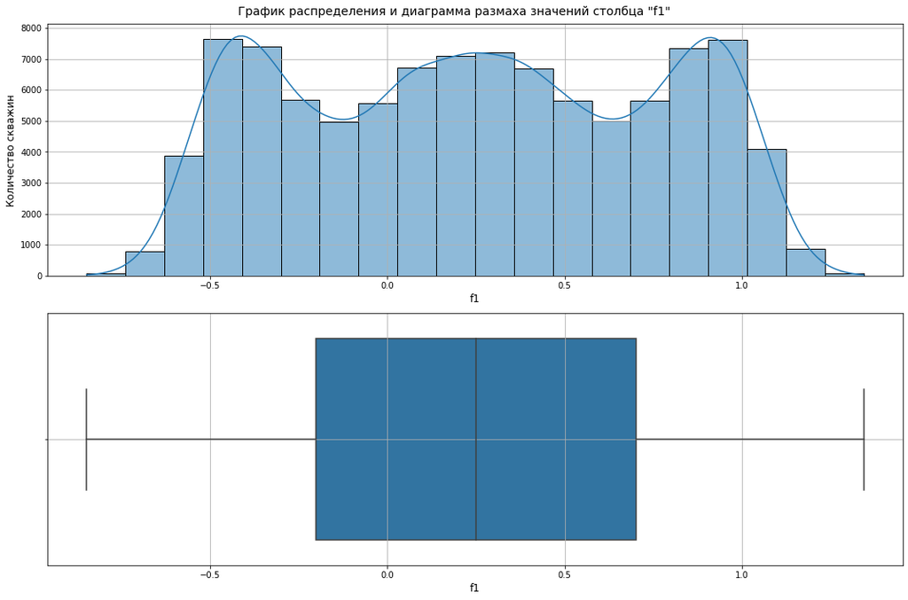

Признак `f2`

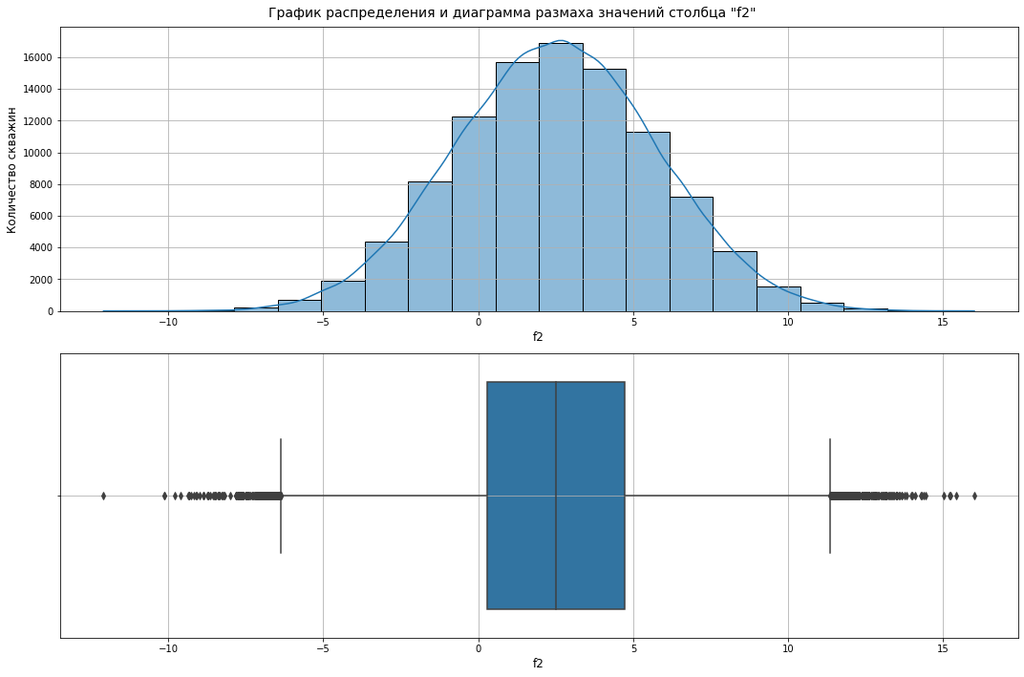

Признак `product`

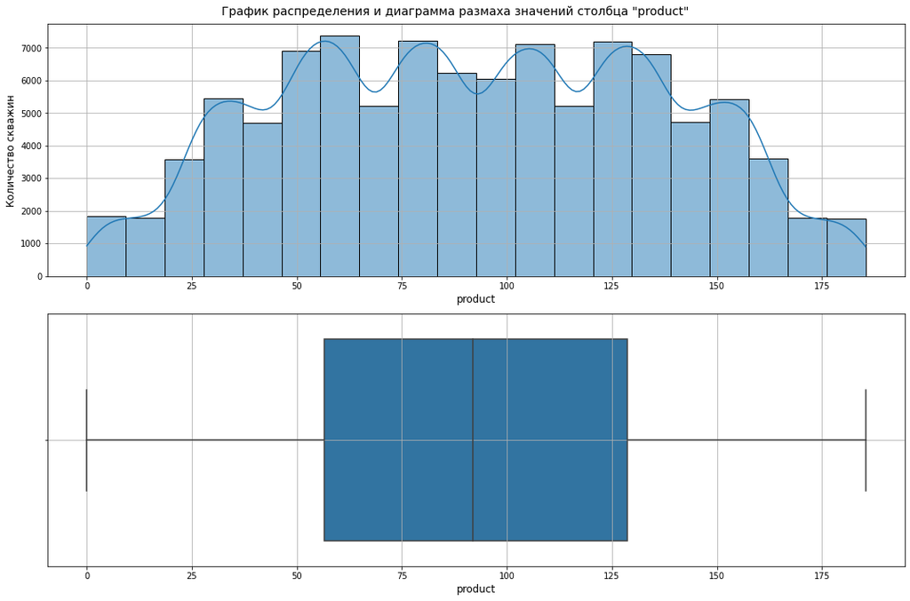

Датафрейм `region_2`

|  | f0 | f1 | f2 | product |
| --- | --- | --- | --- | --- |
| count | 100000.000000 | 100000.000000 | 100000.000000 | 100000.000000 |
| mean | 1.141296 | -4.796579 | 2.494541 | 68.825000 |
| std | 8.965932 | 5.119872 | 1.703572 | 45.944423 |
| min | -31.609576 | -26.358598 | -0.018144 | 0.000000 |
| 25% | -6.298551 | -8.267985 | 1.000021 | 26.953261 |
| 50% | 1.153055 | -4.813172 | 2.011479 | 57.085625 |
| 75% | 8.621015 | -1.332816 | 3.999904 | 107.813044 |
| max | 29.421755 | 18.734063 | 5.019721 | 137.945408 |

Признак `f1`

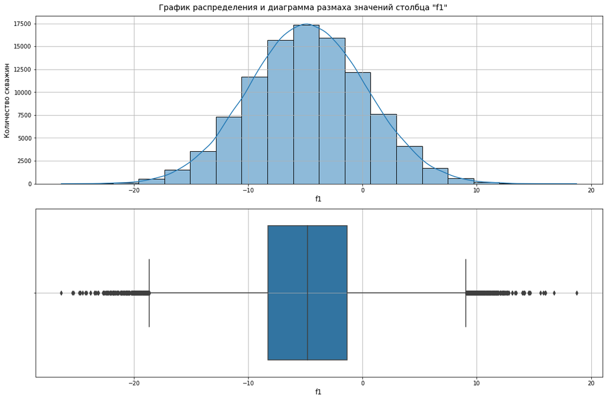

Признак `f2`

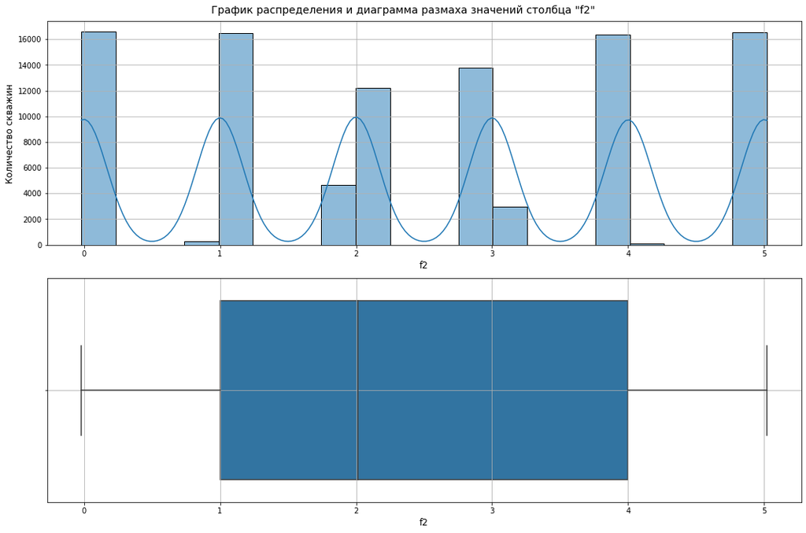

Признак `product`

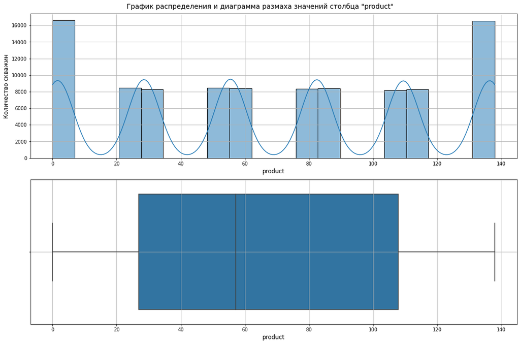

Датафрейм `region_3`

|  | f0 | f1 | f2 | product |
| --- | --- | --- | --- | --- |
| count | 100000.000000 | 100000.000000 | 100000.000000 | 100000.000000 |
| mean | 0.002023 | -0.002081 | 2.495128 | 95.000000 |
| std | 1.732045 | 1.730417 | 3.473445 | 44.749921 |
| min | -8.760004 | -7.084020 | -11.970335 | 0.000000 |
| 25% | -1.162288 | -1.174820 | 0.130359 | 59.450441 |
| 50% | 0.009424 | -0.009482 | 2.484236 | 94.925613 |
| 75% | 1.158535 | 1.163678 | 4.858794 | 130.595027 |
| max | 7.238262 | 7.844801 | 16.739402 | 190.029838 |

Признак `f1`

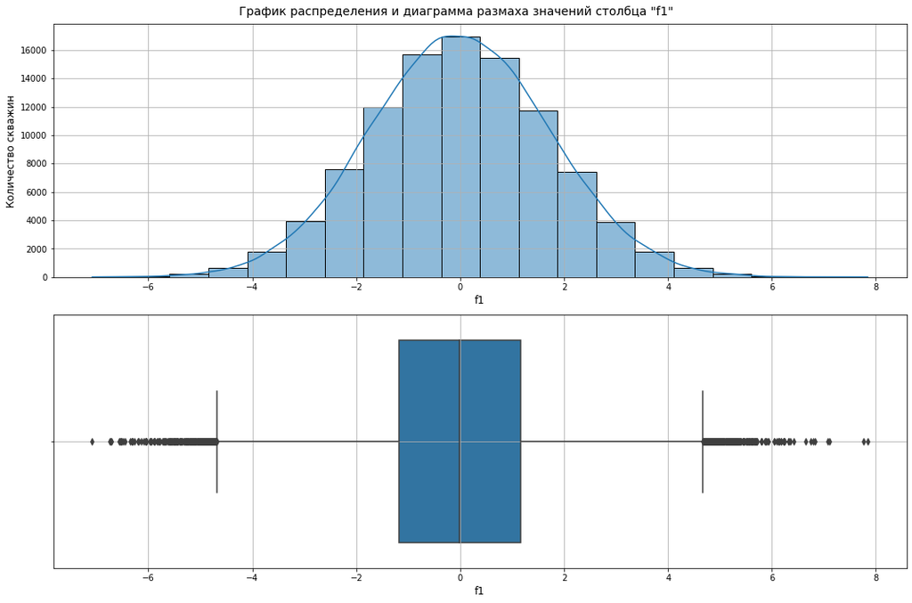

Признак `f2`

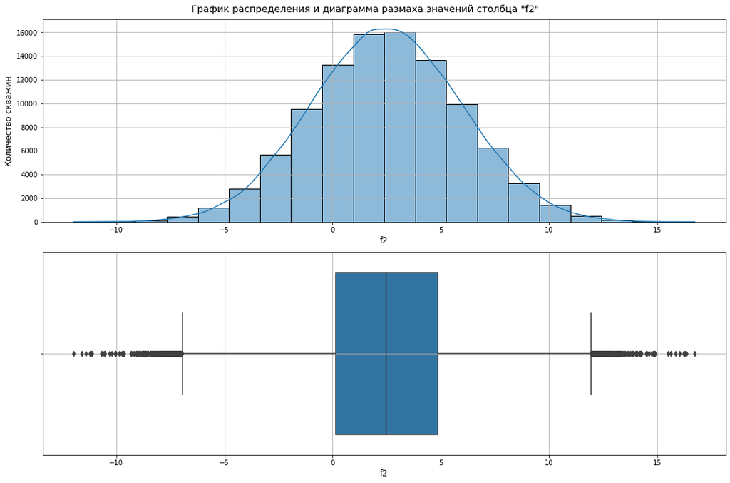

Признак `product`

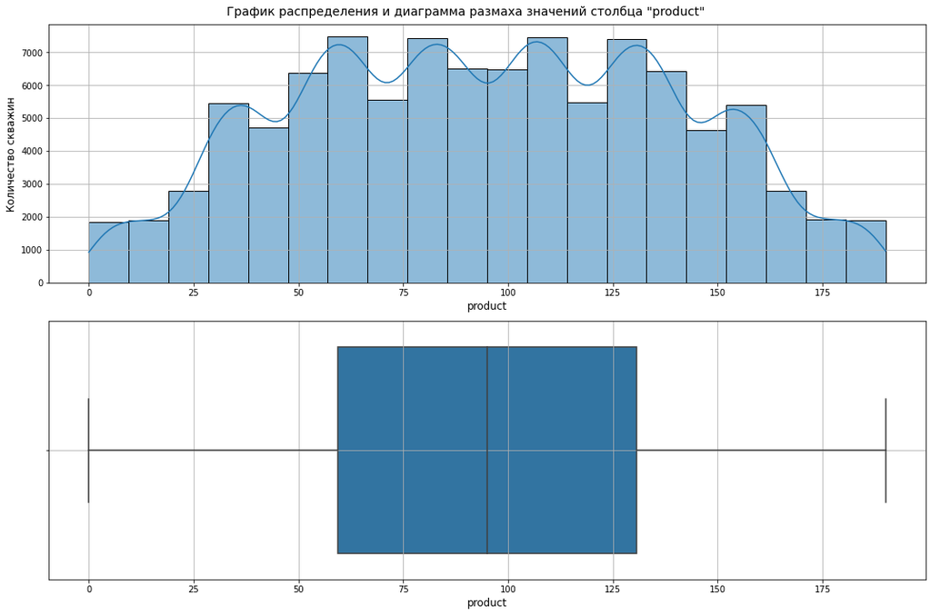

```python
for data_name in all_data:
    data = eval(data_name)

    display(HTML(f'<br><br><br><h1>Датафрейм `{data_name}`</h1>'))
    display(data.describe())

    for column in data.columns[1:]:
        display(HTML(f'<br><h3>Признак `{column}`</h3>'))
        int_plot(data, column)
```

## Комментарий ревьюера ✔️

Эти два графика (гистограмму распределения и боксплот) я бы расположил друг под другом, тогда графики будут друг под другом, и у них как бы будет единая ось икс

Некоторые данные имеют необычное мультимодальное распределение, а также у некоторых на диаграммах размаха отмечаются выбросы. Объяснить и проверить причины этих наблюдений у нас нет возможности в виду закодированности признаков, поэтому лучше всё оставить как есть.

Сравним распределение объёмов запасов скважин по трём регионам.

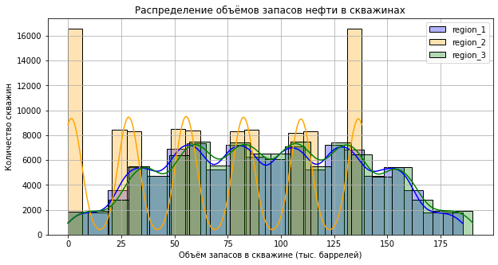

```python
plt.figure(figsize=(10, 5))

colors = ['blue', 'orange', 'green']

for i, data_name in enumerate(all_data):
    data = eval(data_name)

    sns.histplot(data=data['product'],
                 bins=20,
                 alpha=0.3,
                 kde=True,
                 label=data_name,
                 color=colors[i])


plt.title('Распределение объёмов запасов нефти в скважинах')
plt.xlabel('Объём запасов в скважине (тыс. баррелей)')
plt.ylabel('Количество скважин')
plt.legend(loc='upper right')
plt.grid(True)

plt.show()
```

Распределение объемов нефти по 1 и 3 региону очень схожи: имеют почти равномерный разброс от 0 до 190 тыс. баррелей, основная часть сконцентрирована в диапазоне от 55 до 130 тыс. баррелей.

Распределение по второму региону очень необычно - наблюдается четкое деление распередления объема на 6 равных групп с равными интервалами. Изучим уникальные значения.

```python
display(HTML('<h3>Уникальные значения столбца "product" датафрейма `region_2``</h3>'))
region_2['product'].sort_values().unique()
```

Уникальные значения столбца "product" датафрейма `region_2``

```
array([  0.        ,   3.17910258,  26.95326103,  30.13236361,
        53.90652206,  57.08562465,  80.85978309,  84.03888568,
       107.81304413, 110.99214671, 134.76630516, 137.94540774])
```

В столбце всего 12 уникальных значений, что необычно. Таким образом, у второго региона признак является дискретным, в отличие от других регионов.

### Корреляционный анализ

```python
for data_name in all_data:
    data = eval(data_name)

    display(HTML(f'<br><h3>Матрица корреляции признаков `{data_name}`</h3>'))
    display(data.phik_matrix(interval_cols=data.columns)\
                .style.background_gradient('cividis'))
```

Матрица корреляции признаков `region_1`

|  | f0 | f1 | f2 | product |
| --- | --- | --- | --- | --- |
| f0 | 1.000000 | 0.762170 | 0.000000 | 0.215525 |
| f1 | 0.762170 | 1.000000 | 0.000000 | 0.253544 |
| f2 | 0.000000 | 0.000000 | 1.000000 | 0.475901 |
| product | 0.215525 | 0.253544 | 0.475901 | 1.000000 |

Матрица корреляции признаков `region_2`

|  | f0 | f1 | f2 | product |
| --- | --- | --- | --- | --- |
| f0 | 1.000000 | 0.196080 | 0.000000 | 0.628482 |
| f1 | 0.196080 | 1.000000 | 0.000000 | 0.185965 |
| f2 | 0.000000 | 0.000000 | 1.000000 | 0.978936 |
| product | 0.628482 | 0.185965 | 0.978936 | 1.000000 |

Матрица корреляции признаков `region_3`

|  | f0 | f1 | f2 | product |
| --- | --- | --- | --- | --- |
| f0 | 1.000000 | 0.000000 | 0.000000 | 0.201068 |
| f1 | 0.000000 | 1.000000 | 0.000000 | 0.221022 |
| f2 | 0.000000 | 0.000000 | 1.000000 | 0.443287 |
| product | 0.201068 | 0.221022 | 0.443287 | 1.000000 |

В первом регионе высокой корреляцией обладают `'f0' и 'f1'` и умеренной `'f2' и 'product'`. В третьем регионе имеется лишь умеренная связь у `'f2' и 'product'`.

Во втором регионе заметную связь имеют `'f0' и 'product'`, а также черезвычайно высокую корреляцию имеют `'f2' и 'product'`, практически равной 1.

Проверим признаки при помощи коэффициента инфляции дисперсии (VIF).

```python
for data_name in all_data:
    data = eval(data_name)

    display(HTML(f'<br><h3>Коэффициента инфляции дисперсии (VIF) '
                 f'`{data_name}`</h3>'))

    vif_data = pd.DataFrame()
    vif_data['feature'] = data.columns
    vif_data['VIF'] = [variance_inflation_factor(data.values, i) \
                       for i in range(data.shape[1])]

    display(vif_data.style.background_gradient('YlGnBu'))
```

Коэффициента инфляции дисперсии (VIF) `region_1`

|  | feature | VIF |
| --- | --- | --- |
| 0 | f0 | 1.534241 |
| 1 | f1 | 1.275466 |
| 2 | f2 | 2.072358 |
| 3 | product | 2.828466 |

Коэффициента инфляции дисперсии (VIF) `region_2`

|  | feature | VIF |
| --- | --- | --- |
| 0 | f0 | 1.987320 |
| 1 | f1 | 1.828240 |
| 2 | f2 | 4660.924529 |
| 3 | product | 4692.553526 |

Коэффициента инфляции дисперсии (VIF) `region_3`

|  | feature | VIF |
| --- | --- | --- |
| 0 | f0 | 1.000000 |
| 1 | f1 | 1.000004 |
| 2 | f2 | 1.870123 |
| 3 | product | 1.870127 |

В `region_2` признаки `'f2'` и `'product'` имеют черезвычайно выский показатель VIF, что указывает на потенциально сильную корреляцию между переменными-предикторами в модели. В этом случае оценки коэффициентов и p-значения могут быть ненадежными.

Не смотря на это, всё же лучше будет оставить признак `'f2'`, т.к. мы не знаем, какие характеристики зашифрованы в нем, они могут оказаться очень важными.

### Вывод

Нет возможности провести адекватную оценку признаков `'f0'`, `'f1'`, `'f2'` и объяснить их распределения и выборосы, т.к. они зашифрованы.

Распределение объемов нефти по 1 и 3 региону очень схожи: имеют почти равномерный разброс от 0 до 190 тыс. баррелей, основная часть сконцентрирована в диапазоне от 55 до 130 тыс. баррелей.

**Корреляции `region_1`:**

- Высокая: `'f0' и 'f1'`
- Умеренная: `'f2' и 'product'`
- Слабая: `'f0' и 'product'`, `'f1' и 'product'`

**Корреляции `region_2`:**

- Очень высокая: `'f2' и 'product'`
- Заметная: `'f0' и 'product'`
- Слабая: `'f0' и 'f1'`, `'f1' и 'product'`

**Корреляции `region_3`:**

- Умеренная: `'f2' и 'product'`
- Слабая: `'f0' и 'product'`, `'f1' и 'product'`

Вернуться к содержанию

## Обучение и проверка модели

Создадим функцию, в которой будет одновременно проведена подготовка данных, обучение модели, предсказание целевого признака и расчет метрик качества модели.

```python
def model_results(data):

    # Разделение данных на признаки и целевую переменную.
    X = data.drop(['product'], axis=1)
    y = data['product']

    # Разделение данных на обучающую и тестовую выборки.
    X_train, X_test, y_train, y_test = train_test_split(
        X,
        y,
        test_size=0.25,
        random_state=RANDOM_STATE
    )

    # Создание пайплайна.
    pipeline = Pipeline([
        ('scaler', StandardScaler()),
        ('regressor', LinearRegression())
    ])

    # Обучение модели.
    pipeline.fit(X_train, y_train)

    # Предсказания на тестовой выборке.
    y_pred = pipeline.predict(X_test)

    # Вычисление метрик.
    rmse = round(np.sqrt(mean_squared_error(y_test, y_pred)), 2)
    mae = round(mean_absolute_error(y_test, y_pred), 2)
    r2 = round(r2_score(y_test, y_pred), 2)

    # Создание словаря с метриками.
    model_metrics = {
        'rmse': rmse,
        'mae': mae,
        'r2': r2,
        'true_mean': round(y_test.mean(), 2),
        'pred_mean': round(y_pred.mean(), 2)
    }

    true_pred_df = pd.DataFrame({
        'true_product': y_test,
        'pred_product': y_pred
    })

    return model_metrics, true_pred_df
```

Выведем все метрики по регионам в таблицу.

```python
# Создание пустого датафрейма для хранения результатов.
results_df = pd.DataFrame()

for data_name in all_data:
    data = eval(data_name)
    # Преобразуем словарь во временный датафрейм.
    df = pd.DataFrame([model_results(data)[0]], index=[data_name])

    # Собираем в единый датафрейм.
    results_df = pd.concat([results_df, df])

display(results_df)
```

|  | rmse | mae | r2 | true_mean | pred_mean |
| --- | --- | --- | --- | --- | --- |
| region_1 | 37.75 | 31.05 | 0.28 | 92.64 | 92.34 |
| region_2 | 0.89 | 0.71 | 1.00 | 68.69 | 68.70 |
| region_3 | 40.08 | 32.80 | 0.20 | 95.12 | 95.01 |

У регионов 1 и 3 **RMSE** и **MAE** достаточно высокие, что указывает на значительные ошибки предсказания. Низкий коэффициент детерминации R² свидетельствует о слабой объяснительной способности модели.

У региона 2 **RMSE** и **MAE** очень низкие, что указывает на высокую точность предсказаний. Коэффициент детерминации R² равен 1, что свидетельствует о практически идеальной модели - это связано с очень высокой корреляцией целевого признака с `'f2'`.

По всем регионам средние значения истинных и предсказанных значений практически идентичны.

Сохраним результаты предсказанных и правильных ответов на валидационной выборке по каждому региону.

```python
region_1_results = model_results(region_1)[1]
region_2_results = model_results(region_2)[1]
region_3_results = model_results(region_3)[1]

all_results = ['region_1_results', 'region_2_results', 'region_3_results']
```

Выведем первые 5 строк.

```python
for data_name in all_results:
    data = eval(data_name)

    display(HTML(f'<br><h3>Датафрейм `{data_name}`</h3>'))
    display(data.head())
```

Датафрейм `region_1_results`

| id | true_product | pred_product |
| --- | --- | --- |
| kz06D | 70.787822 | 89.912467 |
| nmARb | 78.120803 | 78.870332 |
| CFf4y | 91.914529 | 79.366452 |
| lbPfa | 50.874167 | 90.235009 |
| viqqq | 29.274970 | 58.324255 |

Датафрейм `region_2_results`

| id | true_product | pred_product |
| --- | --- | --- |
| ksHYQ | 3.179103 | 4.102905 |
| ngLE2 | 134.766305 | 136.002882 |
| CIj94 | 53.906522 | 53.526653 |
| lVc5R | 57.085625 | 56.213575 |
| vfVtG | 3.179103 | 2.498790 |

Датафрейм `region_3_results`

| id | true_product | pred_product |
| --- | --- | --- |
| kvoJ2 | 185.360737 | 83.551644 |
| nh6w7 | 49.425217 | 91.398152 |
| CDLub | 61.529167 | 92.783284 |
| lWDr6 | 86.655388 | 97.219335 |
| veJ3P | 89.684475 | 99.005446 |

### Вывод

Мы разбили данные на обучающую и валидационную выборки, отмасштабировали их и обучили модель линейной регрессии при помощи пайплайна.

По полученным метрикам регион 2 показывает наилучшие результаты с точки зрения точности предсказаний и объяснительной способности модели. Высокая корреляция признака f2 с целевым признаком product играет ключевую роль в этом.

Регионы 1 и 3 имеют значительные ошибки предсказаний и низкие значения R², что указывает на необходимость улучшения моделей для этих регионов. Но т.к. данные зашифрованы и у нас нет возможности уточнить детали у заказчиков, улучшить модель с имеющимися данными не получится.

Вернуться к содержанию

## Подготовка к расчёту прибыли

Согласно условиям задачи мы имеем следующие параметры, которые нам необходимо сохранить в переменные:

- Бюджет на разработку скважин в регионе — 10 млрд рублей.
- При разведке региона исследуют 500 точек, из которых с помощью машинного обучения выбирают 200 лучших для разработки.
- При нынешних ценах один баррель сырья приносит 450 рублей дохода. Доход с каждой единицы продукта составляет 450 тыс. рублей, поскольку объём указан в тысячах баррелей.
- После оценки рисков нужно оставить лишь те регионы, в которых вероятность убытков меньше 2.5%. Среди них выбирают регион с наибольшей средней прибылью.

```python
BUDGET = 10_000_000_000

WELLS_NUM = 500

BEST_WELLS_NUM = 200

COST_1000_BARREL = 450_000
```

Рассчитаем средний объем добычи нефти в 200 скважинах, необходимый для достижения безубыточности разработки.

```python
BREAK_EVEN = BUDGET / BEST_WELLS_NUM / COST_1000_BARREL

print(f'Достаточный объём сырья для безубыточной разработки новых скважин: '
      f'{round(BREAK_EVEN, 2)} тыс. баррелей')
```

```
Достаточный объём сырья для безубыточной разработки новых скважин: 111.11 тыс. баррелей
```

```python
display(results_df[results_df.columns[3:5]])
```

|  | true_mean | pred_mean |
| --- | --- | --- |
| region_1 | 92.64 | 92.34 |
| region_2 | 68.69 | 68.70 |
| region_3 | 95.12 | 95.01 |

По ранее полученным значениям среднего объема запасов нефти в регионах мы видим, что ни по одному из регионов средние значения не дотягивают до окупаемости разработки. Нельзя подходить необдуманно к выбору скважины для разработки, т.к. в таком случае компания потерпит большие убытки. Необходимо выявить скважины с наибольшим объемом запасов нефти.

```python
for i, data_name in enumerate(all_results):
    data = eval(data_name)

    n = data['pred_product'][data['pred_product'] >= BREAK_EVEN].count()

    print(f'Количество безубыточных скважин в {all_data[i]}: {n} '
          f'({(n.sum() / data.shape[0]):.2%} 'f'от общего размера)')
```

```
Количество безубыточных скважин в region_1: 5321 (21.28% от общего размера)
Количество безубыточных скважин в region_2: 4556 (18.22% от общего размера)
Количество безубыточных скважин в region_3: 5384 (21.54% от общего размера)
```

Мы видим, что в 1 и 3 регионах 21% скважин имеют объем выше безубыточного порога, но в регионе 2 их меньше - 18%.

Проверим средний запас объёма сырья по 200 прогнозируемо лучшим скважинам в каждом регионе.

```python
# Создаем новые столбцы в таблице для сохранения результатов.
results_df[['best_200_true_mean', 'best_200_pred_mean']] = 0

for i, data_name in enumerate(all_results):
    data = eval(data_name)

    best_wells = \
    data.sort_values(by="pred_product", ascending=False)[:BEST_WELLS_NUM]

    for n, m in [(5, 0), (6, 1)]:
        results_df.loc[results_df.index[i], results_df.columns[n]] = \
            round(best_wells[best_wells.columns[m]].mean(), 2)


display(results_df[results_df.columns[5:]])
```

|  | best_200_true_mean | best_200_pred_mean |
| --- | --- | --- |
| region_1 | 148.25 | 153.60 |
| region_2 | 137.95 | 138.75 |
| region_3 | 138.41 | 148.14 |

Здесь мы видим уже более оптимистичную картину, средний запас сырья по истинным и предсказанным значениям превышает минимальный объем добычи для окупаемости.

### Вывод

Точка безубыточности разработки новой скважины составляет 111 тыс. баррелей на скважину, при этом средний запас в регионах лежит в промежутке 68-95 тыс. баррелей, что меньше на 14-38%.

В регионах всего 18-21% скважин имеют объем выше безубыточного порога, поэтому важно более точно прогнозировать скважины подходящего объема.

Средние значения 200 скважин с максимальным предсказанным объемом нефти во всех регионах равны 139-153 тыс. баррелей и превышают точку безубыточности на 25-37%, что уже говорит о том, что все три региона потенциально прибыльные.

Вернуться к содержанию

## Расчёт прибыли и рисков

Напишем функцию расчета прибыли по 200 прогнозируемо лучшим скважинам.

```python
def wells_profit(data, column):
    best_wells = \
        data.sort_values(by='pred_product',ascending=False)[:BEST_WELLS_NUM]
    profit = best_wells[column].sum() * COST_1000_BARREL - BUDGET
    return profit
```

Считаем прибыль по каждому региону.

```python
# Создаем новые столбцы в таблице для сохранения результатов.
results_df[['true_total_profit', 'pred_total_profit']] = 0

for i, data_name in enumerate(all_results):
    data = eval(data_name)

    for n, m in [(7, 0), (8, 1)]:
        results_df.loc[results_df.index[i], results_df.columns[n]] = \
            round(wells_profit(data, data.columns[m]) / 10**9, 2)

display(HTML(f'<h3>Истинная и прогнозируемая прибыль '
             f'по 200 предсказанным лучшим скважинам (млрд. руб.)</h3>'))
display(results_df[results_df.columns[7:]])
```

Истинная и прогнозируемая прибыль по 200 предсказанным лучшим скважинам (млрд. руб.)

|  | true_total_profit | pred_total_profit |
| --- | --- | --- |
| region_1 | 3.34 | 3.82 |
| region_2 | 2.42 | 2.49 |
| region_3 | 2.46 | 3.33 |

Прогнозы немного выше истинных значений. По истинным значениям каждый регион принесет прибыль в размере от 24 до 33% от вложенных средств, что является хорошим результатом. Самым прибыльным регионом показывает себя регион 1, наименее прибыльным - регион 2.

Создадим функцию `bootstrap_profit` для применения техники Bootstrap с 1000 выборок, чтобы найти распределение прибыли.

```python
def bootstrap_profit(data, n_samples=1000):
    profits = []
    state = np.random.RandomState(12345)
    for _ in range(n_samples):
        sample = data.sample(n=WELLS_NUM, replace=True, random_state=state)
        profit = wells_profit(sample, 'true_product')
        profits.append(profit)
    return np.array(profits)
```

Создадим функцию для построения гистограмм с вертикальными линиями для средних и доверительного интервала.

```python
#
def plot_profit_distribution(profits, mean_profit, lower_bound, upper_bound, region_name):
    plt.figure(figsize=(10, 6))
    sns.histplot(profits, bins=30, kde=True, alpha=0.7)

    # Вертикальные линии для среднего и доверительного интервала.
    plt.axvline(mean_profit, color='red', linestyle='--', label=f'Средняя прибыль: {mean_profit:.2f} млн руб.')
    plt.axvline(lower_bound, color='green', linestyle='--', label=f'Нижняя граница ДИ: {lower_bound:.2f} млн руб.')
    plt.axvline(upper_bound, color='green', linestyle='--', label=f'Верхняя граница ДИ: {upper_bound:.2f} млн руб.')

    # Подписи осей и заголовок.
    plt.xlabel('Прибыль (млн руб.)', fontsize=12)
    plt.ylabel('Частота', fontsize=12)
    plt.title(f'\nРаспределение прибыли для региона {region_name}', fontsize=14)
    plt.legend()
    plt.grid(True)
    plt.show()
```

Рассчитаем среднюю прибыль, 95%-й доверительный интервал и риск убытков. Построим графики.

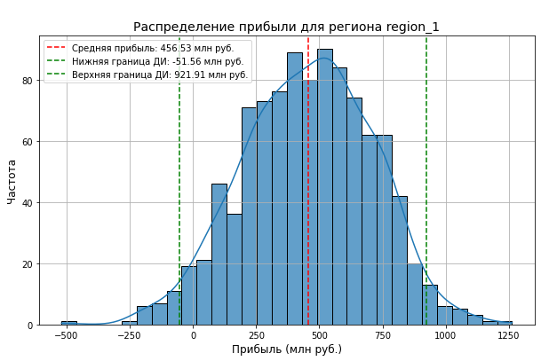

Риск убытков: 3.7%

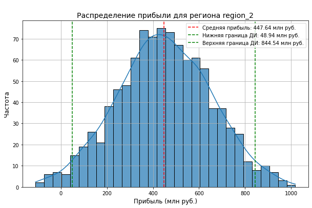

Риск убытков: 1.5%

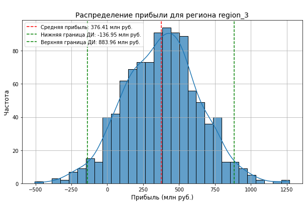

Риск убытков: 7.2%

```python
# Создаем новые столбцы в таблице для сохранения результатов.
results_df[['mean_profit', 'lower_bound', 'upper_bound', 'risk_of_loss']] = 0


for i, data_name in enumerate(all_results):
    data = eval(data_name)

    # Рассчитываем все нужные величины.
    profits = bootstrap_profit(data) / 10**6
    mean_profit = np.mean(profits)
    lower_bound = np.percentile(profits, 2.5)
    upper_bound = np.percentile(profits, 97.5)
    risk_of_loss = (profits < 0).mean()

    # Сохраняем результаты в таблицу.
    results_df.loc[results_df.index[i], 'mean_profit'] = \
        round(mean_profit, 2)
    results_df.loc[results_df.index[i], 'lower_bound'] = \
        round(lower_bound, 2)
    results_df.loc[results_df.index[i], 'upper_bound'] = \
        round(upper_bound, 2)
    results_df.loc[results_df.index[i], 'risk_of_loss'] = risk_of_loss

    # Построение гистограммы с вертикальными линиями.
    plot_profit_distribution(profits, mean_profit, lower_bound, upper_bound, all_data[i])
    display(HTML(f'Риск убытков: {risk_of_loss:.1%}'))
```

```python
display(HTML(f'<h3>Результаты анализа прибыли и рисков</h3>'))
display(results_df[results_df.columns[9:]])
```

Результаты анализа прибыли и рисков

|  | mean_profit | lower_bound | upper_bound | risk_of_loss |
| --- | --- | --- | --- | --- |
| region_1 | 456.53 | -51.56 | 921.91 | 0.037 |
| region_2 | 447.64 | 48.94 | 844.54 | 0.015 |
| region_3 | 376.41 | -136.95 | 883.96 | 0.072 |

### Вывод

В результате проведенных расчетов мы получили следующие результаты:

- Самую высокую чистую прибыль с 200 лучших предсказанных скважин показал регион 1 - 3.34 млрд. руб. Самую низкую чистую прибыль имеет регион 2 - 2.42 млрд. руб.
- Наибольшую среднюю прибыль показывает регион 1 (456.53 млн. руб.), самую маленькую - регион 3 (376.41 мнл. руб.)
- Только у региона 2 разброс средней прибыли не имеет отрицательных значений и имеет самый маленький разброс - от 48.94 до 844.54 млн. руб. Регион 3 имеет самый большой разброс средней прибыли, а также имеет самые большие отрицательные значения (т -136.95 до 883.96 млн. руб.).
- Самый низкий риск убытков, не превышающий порог в 2.5%, показал регион 2 (1.5%). Самый высокий риск имеет регион 3 (7.2%).

Вернуться к содержанию

## Общий вывод

**Описание задачи**

В данном проекте нам было необходимо помочь добывающей компании «ГлавРосГосНефть» решить, где бурить новую скважину, выбрав скважины с самыми высокими оценками значений. Необходимо постройте модель для определения региона, где добыча принесёт наибольшую прибыль, а также проанализировать возможную прибыль и риски.

**Этапы работы**

*Загрузка и первичное изучение информации о данных:*

- Всего у нас представлено данных о 100 000 скважинах по каждому из трех регионов.
- Данные корректны и не требуют проведения предобработки.
- Среди уникальных значений `'id'` обнаружены дубли, но причина их появления неизвестна, поэтому они были оставлены.

*Исследовательский анализ данных:*

- Нет возможности провести адекватную оценку признаков `'f0'`, `'f1'`, `'f2'` и объяснить их распределения и выборосы, т.к. они зашифрованы.
- Распределение объемов нефти по 1 и 3 региону очень схожи: имеют почти равномерный разброс от 0 до 190 тыс. баррелей, основная часть сконцентрирована в диапазоне от 55 до 130 тыс. баррелей.
- В регионе 2 целевой признак имеет черезвычайно высокую корреляцию с признаком `'f2'`, практически равной 1. Такая зависмость в итоге дала нам высокие баллы предсказаний для нашей модели по данному региону.

*Обучение и проверка модели:*

- Мы разбили данные на обучающую и валидационную выборки, отмасштабировали их и обучили модель линейной регрессии при помощи пайплайна.
- По полученным метрикам регион 2 показывает наилучшие результаты с точки зрения точности предсказаний и объяснительной способности модели. Высокая корреляция признака `'f2'` с целевым признаком product играет ключевую роль в этом.
- Регионы 1 и 3 имеют значительные ошибки предсказаний и низкие значения R², что указывает на необходимость улучшения моделей для этих регионов. Но т.к. данные зашифрованы и у нас нет возможности уточнить детали у заказчиков, улучшить модель с имеющимися данными не получится.

**Рекомендации по выбору региона**

Для разработки новых скважин по условиям компании больше всего подходит **регион 2**:

- Разброс средней прибыли у региона самый маленький и не имеет отрицательных значений, что говорит о низкой вероятности понести убытки. Регион имеет низкий риск убытков, не превышающий порог в 2.5%.
- Несмотря на то, что у региона 2 средняя прибыль меньше, чем у региона 1, она уступает лишь на 8.9 млн. руб., поэтому окупаемость разработки скважин будет также очень хорошей.

Вернуться к содержанию